# Bivariate analysis of enteric fever and leptospirosis

Hazlienor

2023-04-14

## prepare environment

load package

```r
library(sf)
library(tidyverse)
library(here)
library(janitor)
```

```r
library(gtsummary)
library(DT)
library(stringr)
library(readxl)
library(broom)
library(tmap)
library(mapview)
library(lubridate)
library(maptools)
library(spatstat)
library(spdep)
library(gridExtra)
library(grid)
library(sparr)
```

## prepare data

read polygon data

```r
kel <- st_read(here("Map",
                    "kelantan.shp"))
```

read population data per mukim per year

```r
kel_mukim <- read_xlsx(here ("mukim.xlsx"))
```

merge population data to polygon

```r
kel_map <- merge(kel,kel_mukim,by.x="MUKIM", by.y="MUKIM", all.x=T, sort=F)
dim(kel_map)
```

```
## [1] 66 49
```

```r
class(kel_map)
```

```
## [1] "sf"         "data.frame"
```

```r
st_crs(kel_map)
```

```
## Coordinate Reference System:
##   User input: Kertau (RSO) / RSO Malaya (m)
##   wkt:
## PROJCRS["Kertau (RSO) / RSO Malaya (m)",
##     BASEGEOGCRS["Kertau (RSO)",
##         DATUM["Kertau (RSO)",
##             ELLIPSOID["Everest 1830 (RSO 1969)",6377295.664,300.8017,
##                 LENGTHUNIT["metre",1]]],
##         PRIMEM["Greenwich",0,
##             ANGLEUNIT["degree",0.0174532925199433]],
##         ID["EPSG",4751]],
##     CONVERSION["Rectified Skew Orthomorphic Malaya Grid (metres)",
##         METHOD["Hotine Oblique Mercator (variant A)",
##             ID["EPSG",9812]],
##         PARAMETER["Latitude of projection centre",4,
##             ANGLEUNIT["degree",0.0174532925199433],
##             ID["EPSG",8811]],
##         PARAMETER["Longitude of projection centre",102.25,
##             ANGLEUNIT["degree",0.0174532925199433],
##             ID["EPSG",8812]],
##         PARAMETER["Azimuth of initial line",323.0257905,
##             ANGLEUNIT["degree",0.0174532925199433],
##             ID["EPSG",8813]],
##         PARAMETER["Angle from Rectified to Skew Grid",323.130102361111,
##             ANGLEUNIT["degree",0.0174532925199433],
##             ID["EPSG",8814]],
##         PARAMETER["Scale factor on initial line",0.99984,
##             SCALEUNIT["unity",1],
##             ID["EPSG",8815]],
##         PARAMETER["False easting",804670.24,
##             LENGTHUNIT["metre",1],
##             ID["EPSG",8806]],
##         PARAMETER["False northing",0,
##             LENGTHUNIT["metre",1],
##             ID["EPSG",8807]]],
##     CS[Cartesian,2],
##         AXIS["(E)",east,
##             ORDER[1],
##             LENGTHUNIT["metre",1]],
##         AXIS["(N)",north,
##             ORDER[2],
##             LENGTHUNIT["metre",1]],
##     USAGE[
##         SCOPE["Engineering survey, topographic mapping."],
##         AREA["Malaysia - West Malaysia onshore."],
##         BBOX[1.21,99.59,6.72,104.6]],
##     ID["EPSG",3168]]
```

load linelisting

```r
linelist2 <- read_xlsx(here ("linelist.xlsx"))
```

merge population data to polygon

```r
kel_map <- merge(kel,kel_mukim,by.x="MUKIM", by.y="MUKIM", all.x=T, sort=F)
dim(kel_map)
```

```
## [1] 66 49
```

```r
class(kel_map)
```

```
## [1] "sf"         "data.frame"
```

```r
st_crs(kel_map)
```

```
## Coordinate Reference System:
##   User input: Kertau (RSO) / RSO Malaya (m)
##   wkt:
## PROJCRS["Kertau (RSO) / RSO Malaya (m)",
##     BASEGEOGCRS["Kertau (RSO)",
##         DATUM["Kertau (RSO)",
##             ELLIPSOID["Everest 1830 (RSO 1969)",6377295.664,300.8017,
##                 LENGTHUNIT["metre",1]]],
##         PRIMEM["Greenwich",0,
##             ANGLEUNIT["degree",0.0174532925199433]],
##         ID["EPSG",4751]],
##     CONVERSION["Rectified Skew Orthomorphic Malaya Grid (metres)",
##         METHOD["Hotine Oblique Mercator (variant A)",
##             ID["EPSG",9812]],
##         PARAMETER["Latitude of projection centre",4,
##             ANGLEUNIT["degree",0.0174532925199433],
##             ID["EPSG",8811]],
##         PARAMETER["Longitude of projection centre",102.25,
##             ANGLEUNIT["degree",0.0174532925199433],
##             ID["EPSG",8812]],
##         PARAMETER["Azimuth of initial line",323.0257905,
##             ANGLEUNIT["degree",0.0174532925199433],
##             ID["EPSG",8813]],
##         PARAMETER["Angle from Rectified to Skew Grid",323.130102361111,
##             ANGLEUNIT["degree",0.0174532925199433],
##             ID["EPSG",8814]],
##         PARAMETER["Scale factor on initial line",0.99984,
##             SCALEUNIT["unity",1],
##             ID["EPSG",8815]],
##         PARAMETER["False easting",804670.24,
##             LENGTHUNIT["metre",1],
##             ID["EPSG",8806]],
##         PARAMETER["False northing",0,
##             LENGTHUNIT["metre",1],
##             ID["EPSG",8807]]],
##     CS[Cartesian,2],
##         AXIS["(E)",east,
##             ORDER[1],
##             LENGTHUNIT["metre",1]],
##         AXIS["(N)",north,
##             ORDER[2],
##             LENGTHUNIT["metre",1]],
##     USAGE[
##         SCOPE["Engineering survey, topographic mapping."],
##         AREA["Malaysia - West Malaysia onshore."],
##         BBOX[1.21,99.59,6.72,104.6]],
##     ID["EPSG",3168]]
```

list cases by year

```r
#extract enteric fever 2016-2022
linelist2 <- read_xlsx(here ("linelist.xlsx"))
listENT_kel <- filter(linelist2, Diagnosis=="Enteric_fever")
listENT_kel16 <- filter(listENT_kel, `Tahun Daftar` =="2016")
listENT_kel17 <- filter(listENT_kel, `Tahun Daftar` =="2017")
listENT_kel18 <- filter(listENT_kel, `Tahun Daftar` =="2018")
listENT_kel19 <- filter(listENT_kel, `Tahun Daftar` =="2019")
listENT_kel20 <- filter(listENT_kel, `Tahun Daftar` =="2020")
listENT_kel21 <- filter(listENT_kel, `Tahun Daftar` =="2021")
listENT_kel22 <- filter(listENT_kel, `Tahun Daftar` =="2022")

#extract leptospirosis 2016-2022
linelist2 <- read_xlsx(here ("linelist.xlsx"))
listLEP_kel <- filter(linelist2, Diagnosis=="Leptospirosis")
LEP_kel16 <- filter(listLEP_kel, `Tahun Daftar` =="2016")
LEP_kel17 <- filter(listLEP_kel, `Tahun Daftar` =="2017")
LEP_kel18 <- filter(listLEP_kel, `Tahun Daftar` =="2018")
LEP_kel19 <- filter(listLEP_kel, `Tahun Daftar` =="2019")
LEP_kel20 <- filter(listLEP_kel, `Tahun Daftar` =="2020")
LEP_kel21 <- filter(listLEP_kel, `Tahun Daftar` =="2021")
LEP_kel22 <- filter(listLEP_kel, `Tahun Daftar` =="2022")
```

count cases per mukim

```r
# join point to polygon
polyENT_kel <- merge(kel_map, listENT_kel, by = c("MUKIM"))

# count cumulative enteric fever per mukim
count_ent <- polyENT_kel%>%
  count(Daerah, MUKIM, AVR) %>%
  ungroup
combined_dataent <- st_join(kel_map, count_ent, by = "MUKIM")

# count cumulative lep fever per mukim
polyLEP_kel <- merge(kel_map, listLEP_kel, by = c("MUKIM"))
count_lep <- polyLEP_kel%>%
  count(Daerah, MUKIM, AVR) %>%
  ungroup
combined_datalep <- st_join(kel_map, count_lep, by = "MUKIM")
```

convert data to spatial format

```r
kel_map.sp <- as(kel_map, "Spatial")
class(kel_map.sp)
```

```
## [1] "SpatialPolygonsDataFrame"
## attr(,"package")
## [1] "sp"
```

transform to owin format

```r
kel_map.owin <- as(kel_map.sp, "owin")
class(kel_map.owin)
```

```
## [1] "owin"
```

mark data with diagnosis (factor)

```r
# transform to sp
loc_both <- st_as_sf(linelist2,
                     coords = c("Longitude (WGS)", "Latitude (WGS)"),
                     crs = 4326)
loc_both <-st_transform(loc_both, 3168)
loc_both.sp <- as(loc_both, "Spatial")

# transform data sp to ppp - save categorical data as factor
all_diag.ppp <- as(loc_both.sp, "ppp")
marks(all_diag.ppp) <- as.factor(loc_both.sp$Diagnosis)
Window(all_diag.ppp) <- kel_map.owin
```

```r
#summary
summary(all_diag.ppp)
```

```
## Marked planar point pattern:  1318 points
## Average intensity 8.717189e-08 points per square unit
##
## *Pattern contains duplicated points*
##
## Coordinates are given to 2 decimal places
## i.e. rounded to the nearest multiple of 0.01 units
##
## Multitype:
##               frequency proportion    intensity
## Enteric_fever       212  0.1608498 1.402158e-08
## Leptospirosis      1106  0.8391502 7.315031e-08
##
## Window: polygonal boundary
## 66 separate polygons (no holes)
##             vertices       area relative.area
## polygon 1        237   23687800       0.00157
## polygon 2        350   56043000       0.00371
## polygon 3        235   18933900       0.00125
## polygon 4        287   17493200       0.00116
## polygon 5        269   41385200       0.00274
## polygon 6        379   39539800       0.00262
## polygon 7        278   61970000       0.00410
## polygon 8        264   15843300       0.00105
## polygon 9        410   30280300       0.00200
## polygon 10       488   31372300       0.00207
## polygon 11       237   23342800       0.00154
## polygon 12       296   33310000       0.00220
## polygon 13       326   21021200       0.00139
## polygon 14       443   16237200       0.00107
## polygon 15       339   16155000       0.00107
## polygon 16       665   20148700       0.00133
## polygon 17       353   61665800       0.00408
## polygon 18       608   23436000       0.00155
## polygon 19       330   20863500       0.00138
## polygon 20       315   44068300       0.00291
## polygon 21       262   22143900       0.00146
## polygon 22       423   24795600       0.00164
## polygon 23       493   11040700       0.00073
## polygon 24       449   94653900       0.00626
```

[output cut: 31 more lines]

```
## polygon 56       562   22848300       0.00151
## polygon 57       324   25812300       0.00171
## polygon 58       328  948995000       0.06280
## polygon 59      1234 4233710000       0.28000
## polygon 60      1035 3057460000       0.20200
## polygon 61       908  836033000       0.05530
## polygon 62       463  608525000       0.04020
## polygon 63       383  824377000       0.05450
## polygon 64       587  341029000       0.02260
## polygon 65       674  304388000       0.02010
## polygon 66       520  706878000       0.04680
## enclosing rectangle: [371629.6, 519479.6] x [503028.2, 690232.8] units
##                      (147900 x 187200 units)
## Window area = 15119600000 square units
## Fraction of frame area: 0.546
```

plot split data

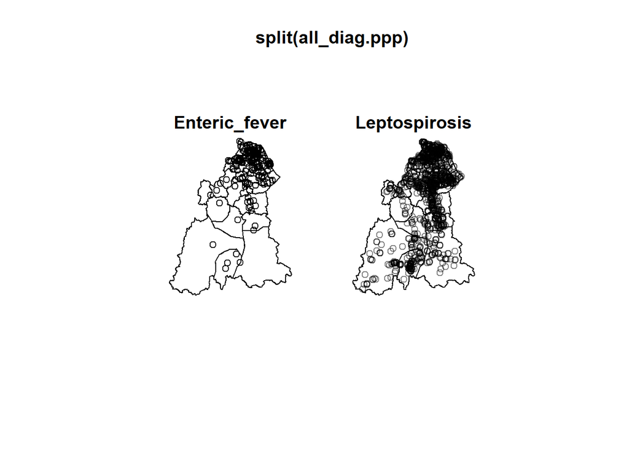

```r
plot(split(all_diag.ppp))
```

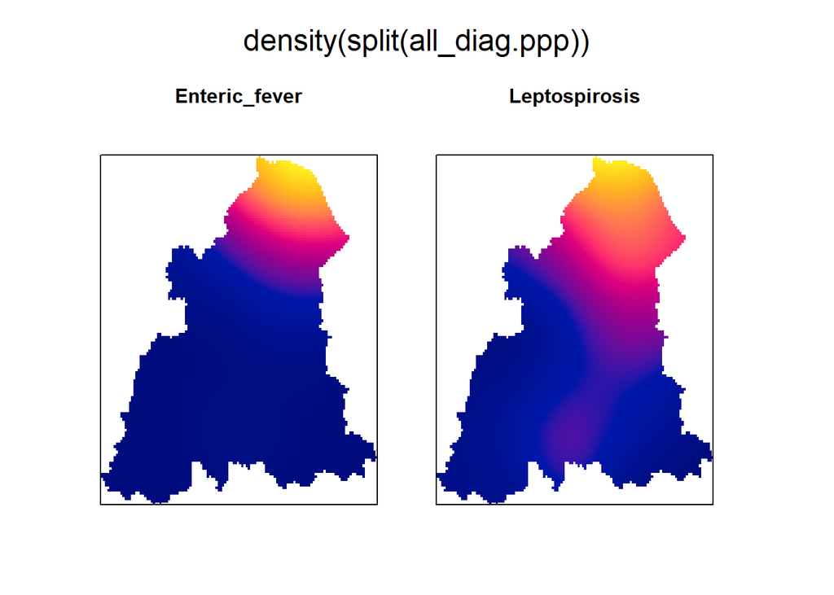

```r
plot(density(split(all_diag.ppp)), ribbon = FALSE)
```

## correlation of cases and population (visual)

plot by tmap

```r
tmap_mode("plot")
```

```
## tmap mode set to plotting
```

```r
cases_mapent <- tm_shape(combined_dataent) + tm_polygons("n") + tm_layout(main.title="Enteric Fever Cases")
pop_map <- tm_shape(kel_map) + tm_polygons("AVR") + tm_layout(main.title="Population")
cases_maplep <- tm_shape(combined_datalep) + tm_polygons("n") + tm_layout(main.title="Leptospirosis Cases")

tmap_arrange(cases_mapent, pop_map, cases_maplep,  ncol=3)   # arrange into 3x1 facets
```

```
## Some legend labels were too wide. These labels have been resized to 0.47, 0.47, 0.47, 0.43. Increase legend.width (argument of tm_layout) to make the legend wider and therefore the labels larger.
```

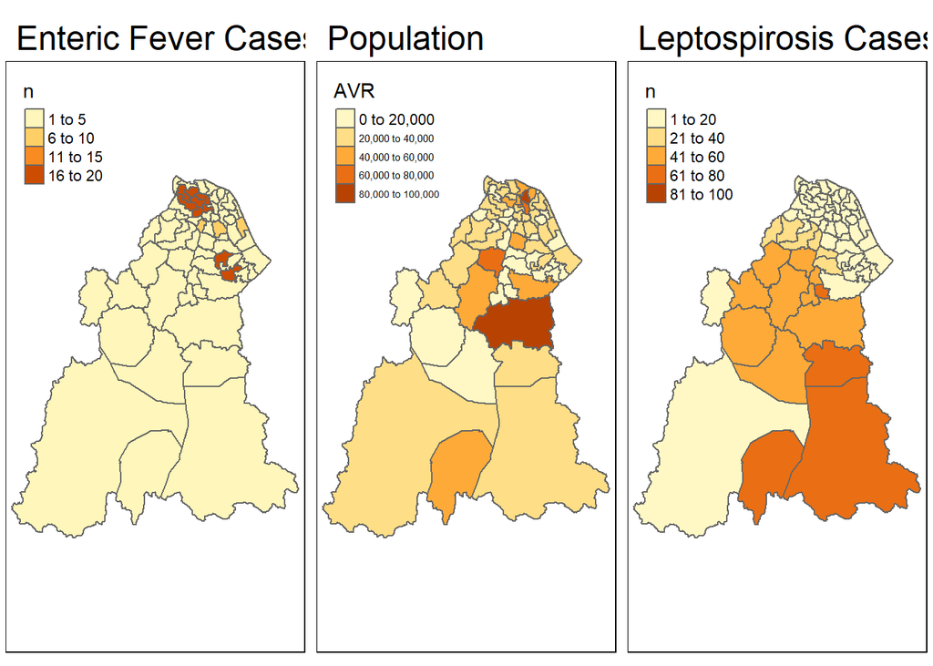

plot by ggplot

```r
pop_map <- ggplot() +
    geom_sf(data = kel_map, aes(fill = AVR), na.rm = FALSE) +
    scale_fill_gradient(low = "white", high = "red", na.value = "grey") +
  labs(fill = "Population") +
  theme_void()

ENT_map <- ggplot() +
    geom_sf(data = combined_dataent, aes(fill = n), na.rm = FALSE) +
    scale_fill_gradient(low = "white", high = "red", na.value = "grey") +
  labs(fill = "Enteric Fever Cases") +
  theme_void()

LEP_map <- ggplot() +
    geom_sf(data = combined_datalep, aes(fill = n), na.rm = FALSE) +
    scale_fill_gradient(low = "white", high = "red", na.value = "grey") +
  labs(fill = "Leptospirosis Cases") +
  theme_void()
```

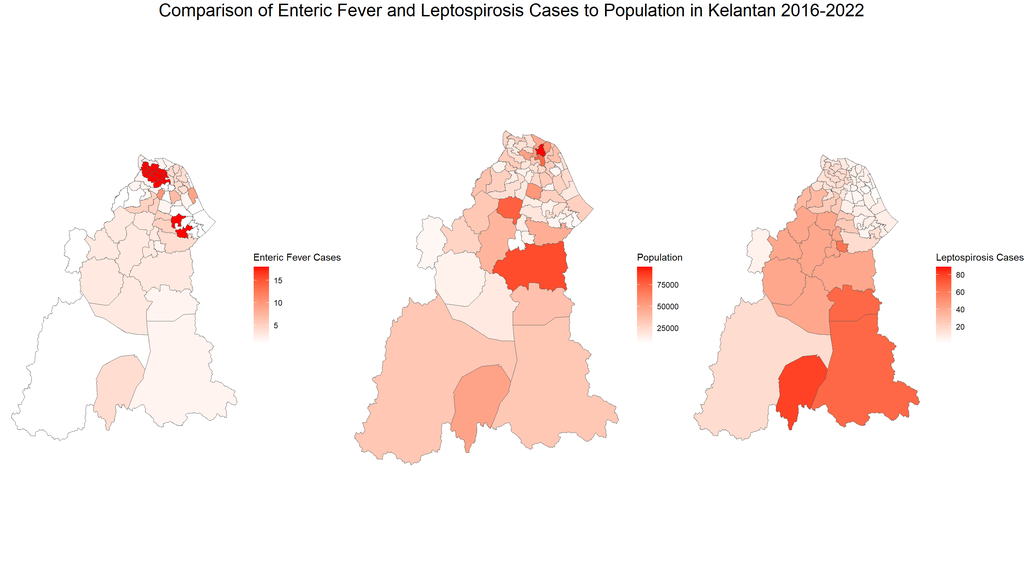

```r
grid.arrange(ENT_map, pop_map, LEP_map, nrow=1, top=textGrob("Comparison of Enteric Fever and Leptospirosis Cases to Population in Kelantan 2016-2022", gp = gpar(fontsize = 20)))
```

# spatial relative risk (sparr package)

cumulative cases

```r
# split data
diag_lep <- split(all_diag.ppp)$Leptospirosis
diag_ent <- split(all_diag.ppp)$Enteric_fever

# Compute a symmetric (pooled) adaptive relative risk estimate
# with tolerance contours
h0 <- OS(all_diag.ppp, nstar="geometric")
diag_rr <- risk(diag_lep, diag_ent, h0=h0, adapt=TRUE, tolerate=TRUE,
                hp=OS(all_diag.ppp)/2, pilot.symmetry="pooled", davies.baddeley=0.05)
```

```
## Estimating case density...Done.
## Estimating control density...Done.
## Calculating tolerance contours...Done.
```

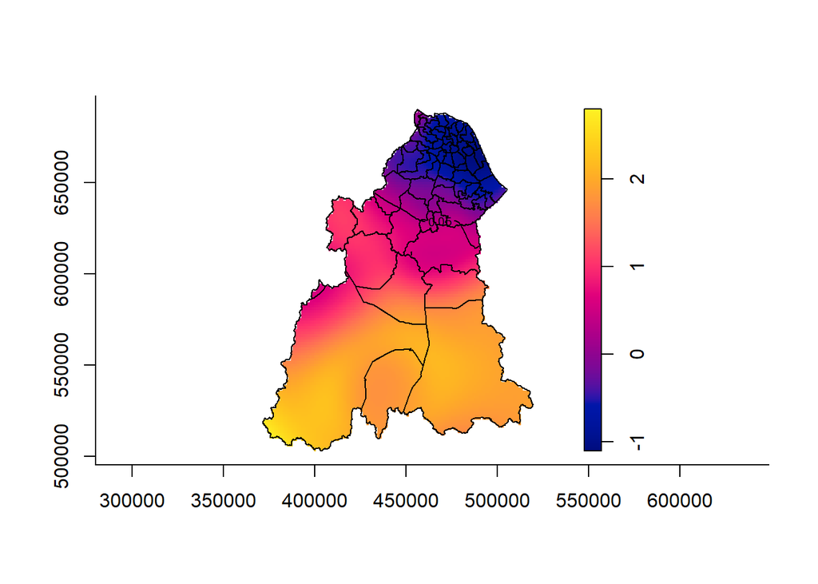

```r
plot(diag_rr)
```

prepare file for spatial relative risk by year

```r
# extract list contain both diagnosis by year
list2016 <- linelist2 %>%
  filter(`Tahun Daftar` == "2016")
list2017 <- linelist2 %>%
  filter(`Tahun Daftar` == "2017")
list2018 <- linelist2 %>%
  filter(`Tahun Daftar` == "2018")
list2019 <- linelist2 %>%
  filter(`Tahun Daftar` == "2019")
list2020 <- linelist2 %>%
  filter(`Tahun Daftar` == "2020")
list2021 <- linelist2 %>%
  filter(`Tahun Daftar` == "2021")
list2022 <- linelist2 %>%
  filter(`Tahun Daftar` == "2022")

# transform to sf
list2016.sf <- st_as_sf(list2017,
                     coords = c("Longitude (WGS)", "Latitude (WGS)"),
                     crs = 4326)
list2017.sf <- st_as_sf(list2017,
                     coords = c("Longitude (WGS)", "Latitude (WGS)"),
                     crs = 4326)
list2018.sf <- st_as_sf(list2018,
                     coords = c("Longitude (WGS)", "Latitude (WGS)"),
                     crs = 4326)
list2019.sf <- st_as_sf(list2019,
                     coords = c("Longitude (WGS)", "Latitude (WGS)"),
                     crs = 4326)
list2020.sf <- st_as_sf(list2020,
                     coords = c("Longitude (WGS)", "Latitude (WGS)"),
                     crs = 4326)
list2021.sf <- st_as_sf(list2021,
                     coords = c("Longitude (WGS)", "Latitude (WGS)"),
                     crs = 4326)
list2022.sf <- st_as_sf(list2022,
                     coords = c("Longitude (WGS)", "Latitude (WGS)"),
                     crs = 4326)

# transform to RSO
loc_list2016.sf <-st_transform(list2016.sf, 3168)
loc_list2017.sf <-st_transform(list2017.sf, 3168)
loc_list2018.sf <-st_transform(list2018.sf, 3168)
loc_list2019.sf <-st_transform(list2019.sf, 3168)
loc_list2020.sf <-st_transform(list2020.sf, 3168)
loc_list2021.sf <-st_transform(list2021.sf, 3168)
loc_list2022.sf <-st_transform(list2022.sf, 3168)

# transform to sp
loc_list2016.sp <- as(loc_list2016.sf, "Spatial")
loc_list2017.sp <- as(loc_list2017.sf, "Spatial")
loc_list2018.sp <- as(loc_list2018.sf, "Spatial")
loc_list2019.sp <- as(loc_list2019.sf, "Spatial")
loc_list2020.sp <- as(loc_list2020.sf, "Spatial")
loc_list2021.sp <- as(loc_list2021.sf, "Spatial")
loc_list2022.sp <- as(loc_list2022.sf, "Spatial")

# transform data sp to ppp
loc_list2016.ppp <- as(loc_list2016.sp, "ppp")
loc_list2017.ppp <- as(loc_list2017.sp, "ppp")
loc_list2018.ppp <- as(loc_list2018.sp, "ppp")
loc_list2019.ppp <- as(loc_list2019.sp, "ppp")
loc_list2020.ppp <- as(loc_list2020.sp, "ppp")
loc_list2021.ppp <- as(loc_list2021.sp, "ppp")
loc_list2022.ppp <- as(loc_list2022.sp, "ppp")

# save categorical data as factor (marked data)
marks(loc_list2016.ppp) <- as.factor(loc_list2016.sp$Diagnosis)
marks(loc_list2017.ppp) <- as.factor(loc_list2017.sp$Diagnosis)
marks(loc_list2018.ppp) <- as.factor(loc_list2018.sp$Diagnosis)
marks(loc_list2019.ppp) <- as.factor(loc_list2019.sp$Diagnosis)
marks(loc_list2020.ppp) <- as.factor(loc_list2020.sp$Diagnosis)
marks(loc_list2021.ppp) <- as.factor(loc_list2021.sp$Diagnosis)
marks(loc_list2022.ppp) <- as.factor(loc_list2022.sp$Diagnosis)

# set window
Window(loc_list2016.ppp) <- kel_map.owin
Window(loc_list2017.ppp) <- kel_map.owin
Window(loc_list2018.ppp) <- kel_map.owin
Window(loc_list2019.ppp) <- kel_map.owin
Window(loc_list2020.ppp) <- kel_map.owin
Window(loc_list2021.ppp) <- kel_map.owin
Window(loc_list2022.ppp) <- kel_map.owin
```

calculate spatial relative risk by year

```r
# 2016
# split into diagnosis
diag_lep16 <- split(loc_list2016.ppp)$Leptospirosis
diag_ent16 <- split(loc_list2016.ppp)$Enteric_fever

# Compute a symmetric (pooled) adaptive relative risk estimate
# with tolerance contours
h0_16 <- OS(loc_list2016.ppp, nstar="geometric")
diag_rr16 <- risk(diag_lep16, diag_ent16, h0=h0_16, adapt=TRUE, tolerate=TRUE,
                hp=OS(loc_list2016.ppp)/2, pilot.symmetry="pooled", davies.baddeley=0.05)
```

```
## Estimating case density...Done.
## Estimating control density...Done.
## Calculating tolerance contours...Done.
```

```r
# 2017
diag_lep17 <- split(loc_list2017.ppp)$Leptospirosis
diag_ent17 <- split(loc_list2017.ppp)$Enteric_fever
h0_17 <- OS(loc_list2017.ppp, nstar="geometric")
diag_rr17 <- risk(diag_lep17, diag_ent17, h0=h0_17, adapt=TRUE, tolerate=TRUE,
                hp=OS(loc_list2017.ppp)/2, pilot.symmetry="pooled", davies.baddeley=0.05)
```

```
## Estimating case density...Done.
## Estimating control density...Done.
## Calculating tolerance contours...Done.
```

```r
# 2018
diag_lep18 <- split(loc_list2018.ppp)$Leptospirosis
diag_ent18 <- split(loc_list2018.ppp)$Enteric_fever
h0_18 <- OS(loc_list2018.ppp, nstar="geometric")
diag_rr18 <- risk(diag_lep18, diag_ent18, h0=h0_18, adapt=TRUE, tolerate=TRUE,
                hp=OS(loc_list2018.ppp)/2, pilot.symmetry="pooled", davies.baddeley=0.05)
```

```
## Estimating case density...Done.
## Estimating control density...Done.
## Calculating tolerance contours...Done.
```

```r
# 2019
diag_lep19 <- split(loc_list2019.ppp)$Leptospirosis
diag_ent19 <- split(loc_list2019.ppp)$Enteric_fever
h0_19 <- OS(loc_list2019.ppp, nstar="geometric")
diag_rr19 <- risk(diag_lep19, diag_ent19, h0=h0_19, adapt=TRUE, tolerate=TRUE,
                hp=OS(loc_list2019.ppp)/2, pilot.symmetry="pooled", davies.baddeley=0.05)
```

```
## Estimating case density...Done.
## Estimating control density...Done.
## Calculating tolerance contours...Done.
```

```r
# 2020
diag_lep20 <- split(loc_list2020.ppp)$Leptospirosis
diag_ent20 <- split(loc_list2020.ppp)$Enteric_fever
h0_20 <- OS(loc_list2020.ppp, nstar="geometric")
diag_rr20 <- risk(diag_lep20, diag_ent20, h0=h0_20, adapt=TRUE, tolerate=TRUE,
                hp=OS(loc_list2020.ppp)/2, pilot.symmetry="pooled", davies.baddeley=0.05)
```

```
## Estimating case density...Done.
## Estimating control density...Done.
## Calculating tolerance contours...Done.
```

```r
# 2021
diag_lep21 <- split(loc_list2021.ppp)$Leptospirosis
diag_ent21 <- split(loc_list2021.ppp)$Enteric_fever
h0_21 <- OS(loc_list2021.ppp, nstar="geometric")
diag_rr21 <- risk(diag_lep21, diag_ent21, h0=h0_21, adapt=TRUE, tolerate=TRUE,
                hp=OS(loc_list2021.ppp)/2, pilot.symmetry="pooled", davies.baddeley=0.05)
```

```
## Estimating case density...Done.
## Estimating control density...Done.
## Calculating tolerance contours...Done.
```

```r
# 2022
diag_lep22 <- split(loc_list2022.ppp)$Leptospirosis
diag_ent22 <- split(loc_list2022.ppp)$Enteric_fever
h0_22 <- OS(loc_list2022.ppp, nstar="geometric")
diag_rr22 <- risk(diag_lep22, diag_ent22, h0=h0_22, adapt=TRUE, tolerate=TRUE,
                hp=OS(loc_list2022.ppp)/2, pilot.symmetry="pooled", davies.baddeley=0.05)
```

```
## Estimating case density...Done.
## Estimating control density...Done.
## Calculating tolerance contours...Done.
```

plot spatial relative risk by year

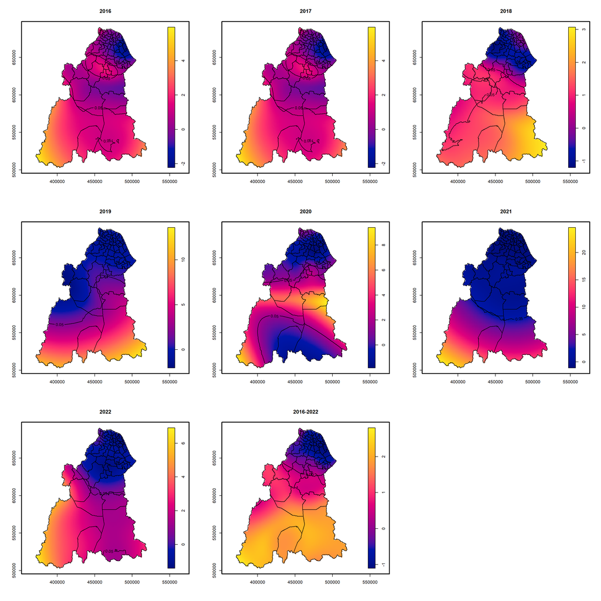

```r
par( mfrow= c(3,3) )
plot(diag_rr16, main = "2016", cex.main = 8, cex.lab = 6)
box(lwd = 2)
plot(diag_rr17, main = "2017", cex.main = 8, cex.lab = 6)
box(lwd = 2)
plot(diag_rr18, main = "2018", cex.main = 8, cex.lab = 6)
box(lwd = 2)
plot(diag_rr19, main = "2019", cex.main = 8, cex.lab = 6)
box(lwd = 2)
plot(diag_rr20, main = "2020", cex.main = 8, cex.lab = 6)
box(lwd = 2)
plot(diag_rr21, main = "2021", cex.main = 8, cex.lab = 6)
box(lwd = 2)
plot(diag_rr22, main = "2022", cex.main = 8, cex.lab = 6)
box(lwd = 2)
plot(diag_rr, main = "2016-2022", cex.main = 8, cex.lab = 6)
box(lwd = 2)
```

# spatially-varying probability (spatstat)

Estimates the spatially-varying probability of each type of point, using kernel smoothing - A value of 0 for a particular label suggests no occurrence of that label at that location, while a value of 1 suggests a definite occurrence. - the probability of the case to be leptospirosis case in that area as opposed to others, case = leptospirosis, control = enteric fever

```r
# calculate risk
relrisk_all <- relrisk.ppp(all_diag.ppp, casecontrol=TRUE, at="pixels")
relrisk_16 <- relrisk.ppp(loc_list2016.ppp, casecontrol=TRUE, at="pixels")
relrisk_17 <- relrisk.ppp(loc_list2017.ppp, casecontrol=TRUE, at="pixels")
relrisk_18 <- relrisk.ppp(loc_list2018.ppp, casecontrol=TRUE, at="pixels")
relrisk_19 <- relrisk.ppp(loc_list2019.ppp, casecontrol=TRUE, at="pixels")
relrisk_20 <- relrisk.ppp(loc_list2020.ppp, casecontrol=TRUE, at="pixels")
```

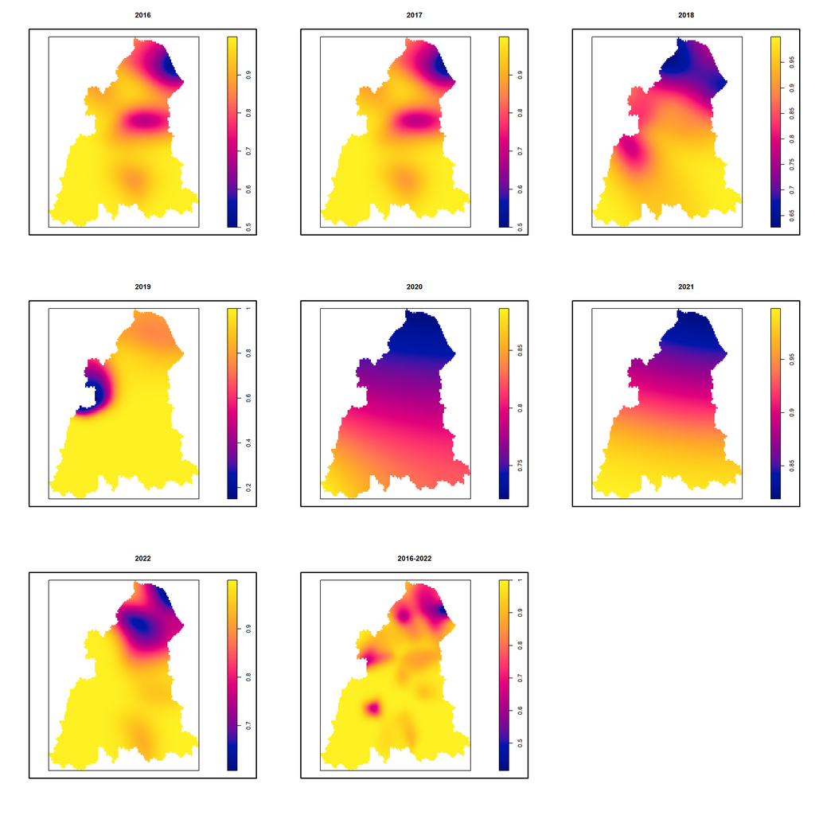

```r
relrisk_21 <- relrisk.ppp(loc_list2021.ppp, casecontrol=TRUE, at="pixels")
relrisk_22 <- relrisk.ppp(loc_list2022.ppp, casecontrol=TRUE, at="pixels")

par(mfrow=c(3,3))
plot(relrisk_16, main = "2016", cex.main = 8, cex.lab = 6)
box(lwd = 2)
plot(relrisk_17, main = "2017", cex.main = 8, cex.lab = 6)
box(lwd = 2)
plot(relrisk_18, main = "2018", cex.main = 8, cex.lab = 6)
box(lwd = 2)
plot(relrisk_19, main = "2019", cex.main = 8, cex.lab = 6)
box(lwd = 2)
plot(relrisk_20, main = "2020", cex.main = 8, cex.lab = 6)
box(lwd = 2)
plot(relrisk_21, main = "2021", cex.main = 8, cex.lab = 6)
box(lwd = 2)
plot(relrisk_22, main = "2022", cex.main = 8, cex.lab = 6)
box(lwd = 2)
plot(relrisk_all, main = "2016-2022", cex.main = 8, cex.lab = 6)
box(lwd = 2)
```

# bivariate L function

calculate bivariate L function

```r
Lboth <- alltypes(all_diag.ppp, "L")
```

```r
Lboth16 <- alltypes(loc_list2016.ppp, "L")
Lboth17 <- alltypes(loc_list2017.ppp, "L")
Lboth18 <- alltypes(loc_list2018.ppp, "L")
Lboth19 <- alltypes(loc_list2019.ppp, "L")
Lboth20 <- alltypes(loc_list2020.ppp, "L")
Lboth21 <- alltypes(loc_list2021.ppp, "L")
Lboth22 <- alltypes(loc_list2022.ppp, "L")
```

plot bivariate L graph by year

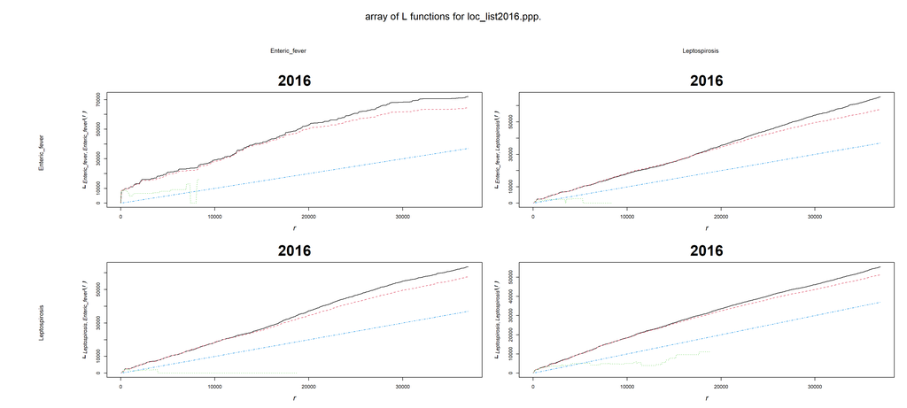

```r
plot(Lboth16, main = "2016", cex.main = 3, cex.lab = 1.5)
```

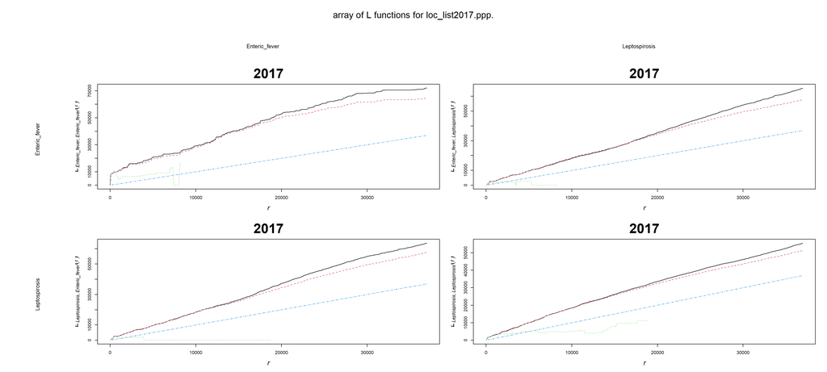

```r
plot(Lboth17, main = "2017", cex.main = 3, cex.lab = 1.5)
```

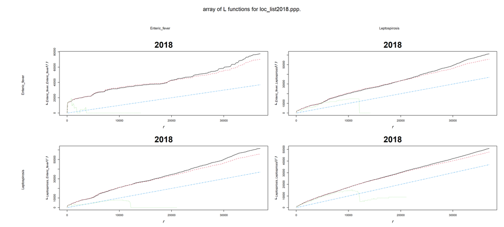

```r
plot(Lboth18, main = "2018", cex.main = 3, cex.lab = 1.5)
```

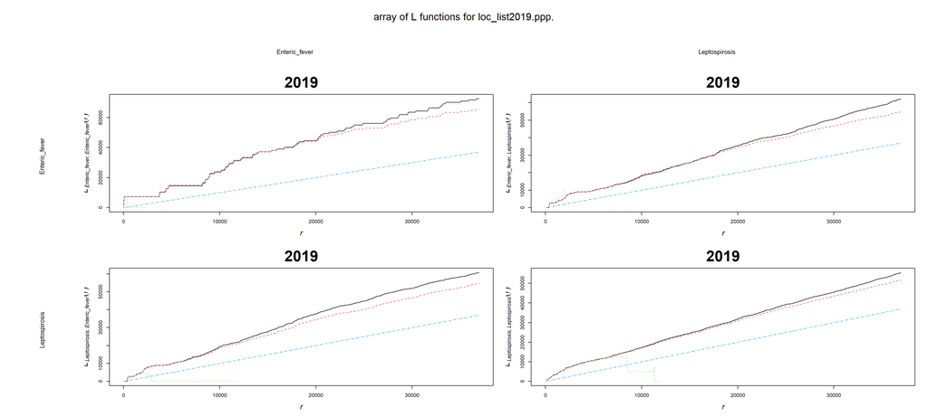

```r
plot(Lboth19, main = "2019", cex.main = 3, cex.lab = 1.5)
```

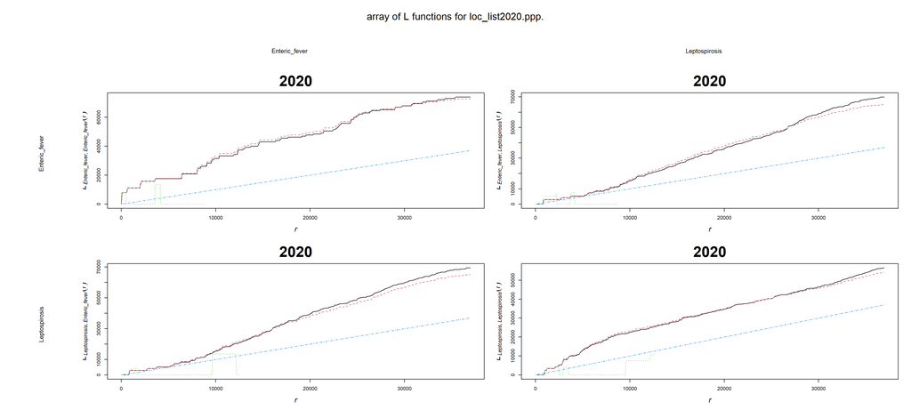

```r
plot(Lboth20, main = "2020", cex.main = 3, cex.lab = 1.5)
```

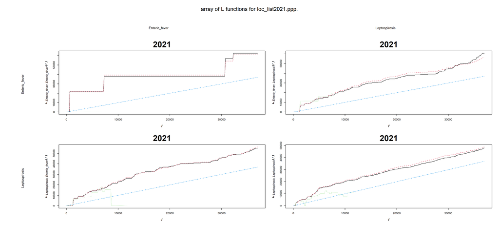

```r
plot(Lboth21, main = "2021", cex.main = 3, cex.lab = 1.5)
```

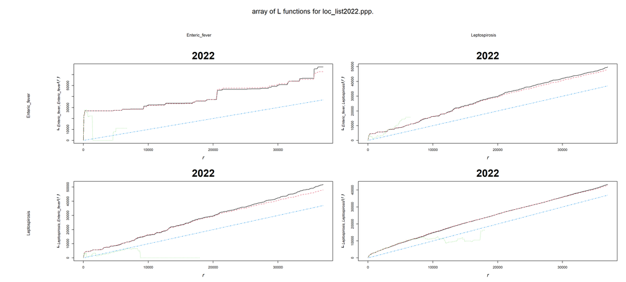

```r
plot(Lboth22, main = "2022", cex.main = 3, cex.lab = 1.5)
```

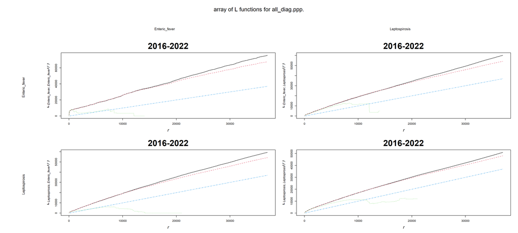

```r
plot(Lboth, main = "2016-2022", cex.main = 3, cex.lab = 1.5)
```

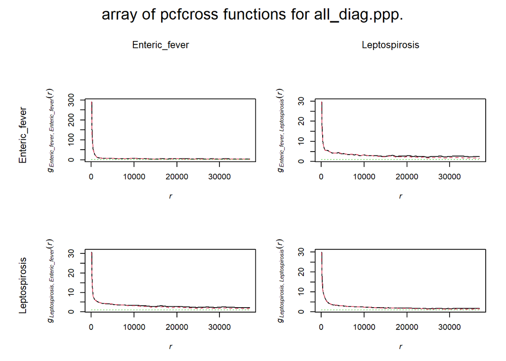

```r
#plot estimates of the bivariate pair correlation functions
Lbothest <- plot(alltypes(all_diag.ppp, pcfcross))
```

```r
# bivariate G-functions
Gboth16 <- alltypes(loc_list2016.ppp, Gcross)
Gboth17 <- alltypes(loc_list2017.ppp, Gcross)
Gboth18 <- alltypes(loc_list2018.ppp, Gcross)
Gboth19 <- alltypes(loc_list2019.ppp, Gcross)
Gboth20 <- alltypes(loc_list2020.ppp, Gcross)
Gboth21 <- alltypes(loc_list2021.ppp, Gcross)
Gboth22 <- alltypes(loc_list2022.ppp, Gcross)
Gboth <- alltypes(all_diag.ppp, Gcross)
```

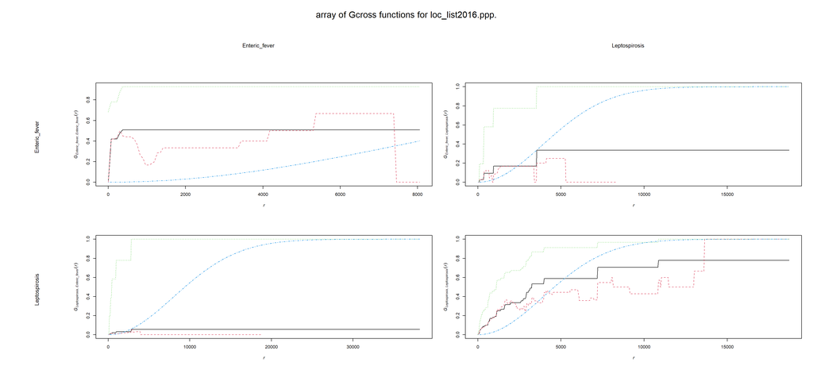

```r
# plot bivariate G-functions
plot(Gboth16)
```

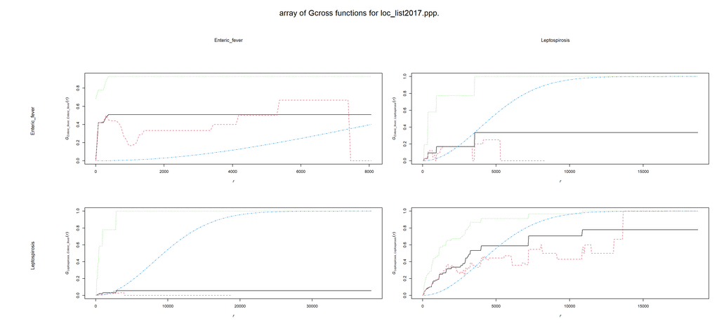

```r
plot(Gboth17)
```

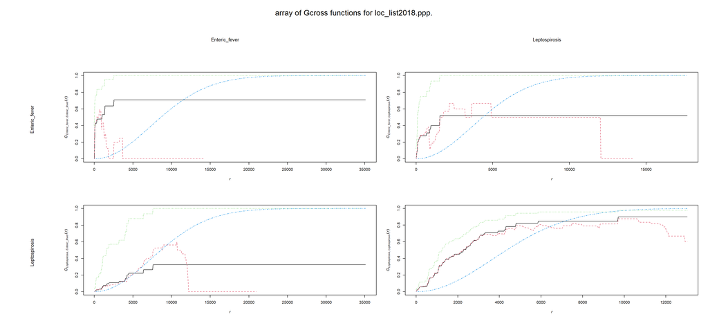

```r
plot(Gboth18)
```

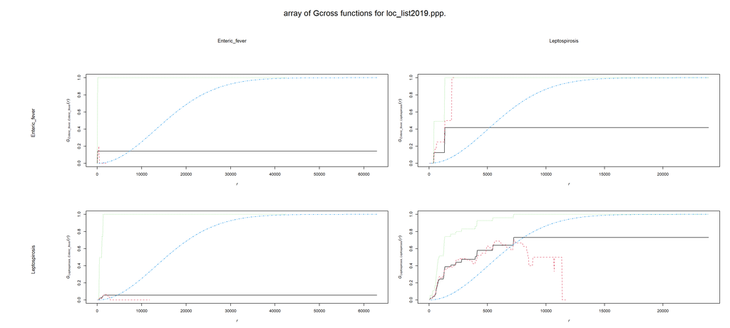

```r
plot(Gboth19)
```

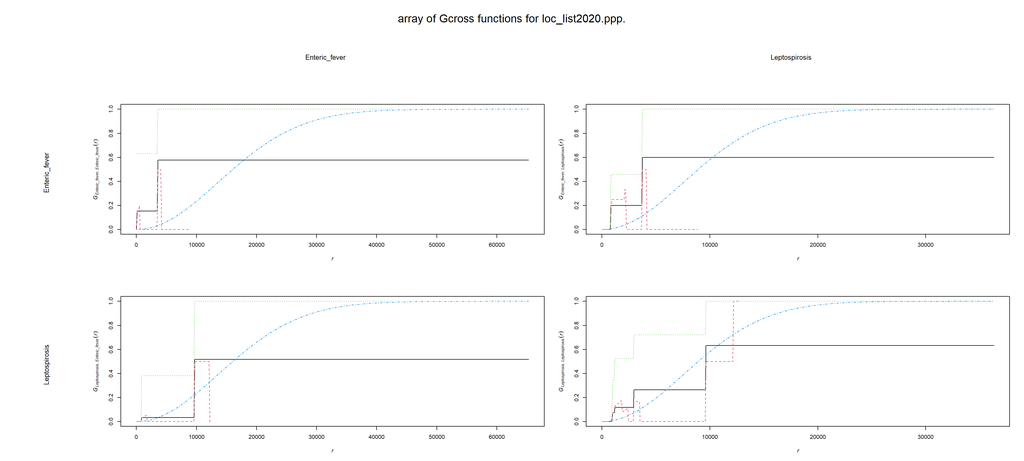

```r
plot(Gboth20)
```

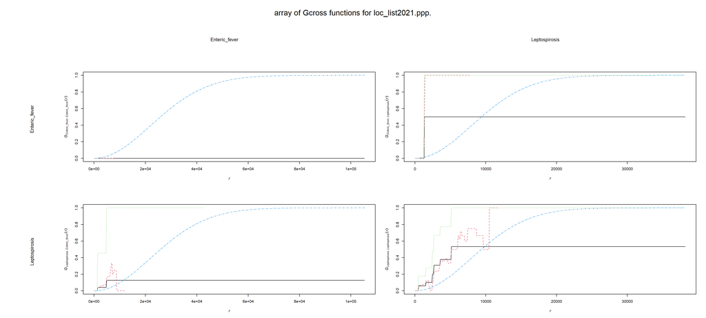

```r
plot(Gboth21)
```

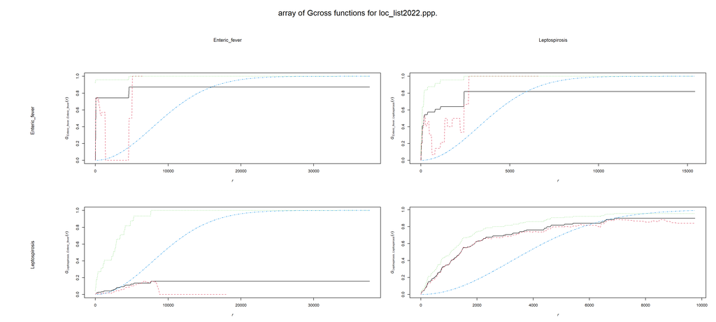

```r
plot(Gboth22)
```

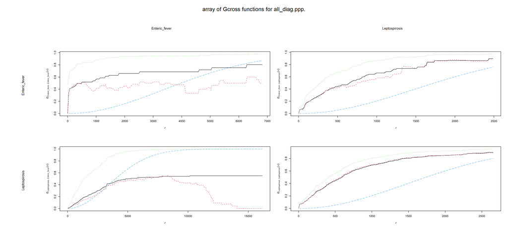

```r
plot(Gboth)
```

# calculate Gdot function

```r
Gdotall <- alltypes(all_diag.ppp, Gdot)
Gdot16 <- alltypes(loc_list2016.ppp, Gdot)
Gdot17 <- alltypes(loc_list2017.ppp, Gdot)
Gdot18 <- alltypes(loc_list2018.ppp, Gdot)
Gdot19 <- alltypes(loc_list2019.ppp, Gdot)
Gdot20 <- alltypes(loc_list2020.ppp, Gdot)
Gdot21 <- alltypes(loc_list2021.ppp, Gdot)
Gdot22 <- alltypes(loc_list2022.ppp, Gdot)
```

# plot Gdot

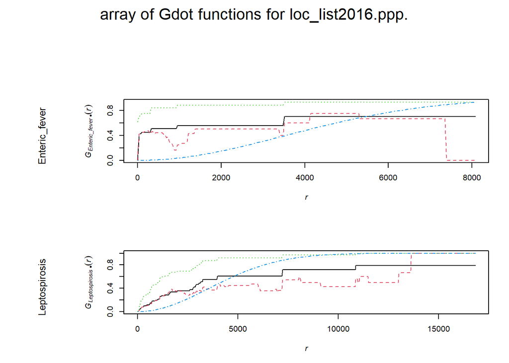

```r
plot(Gdot16)
```

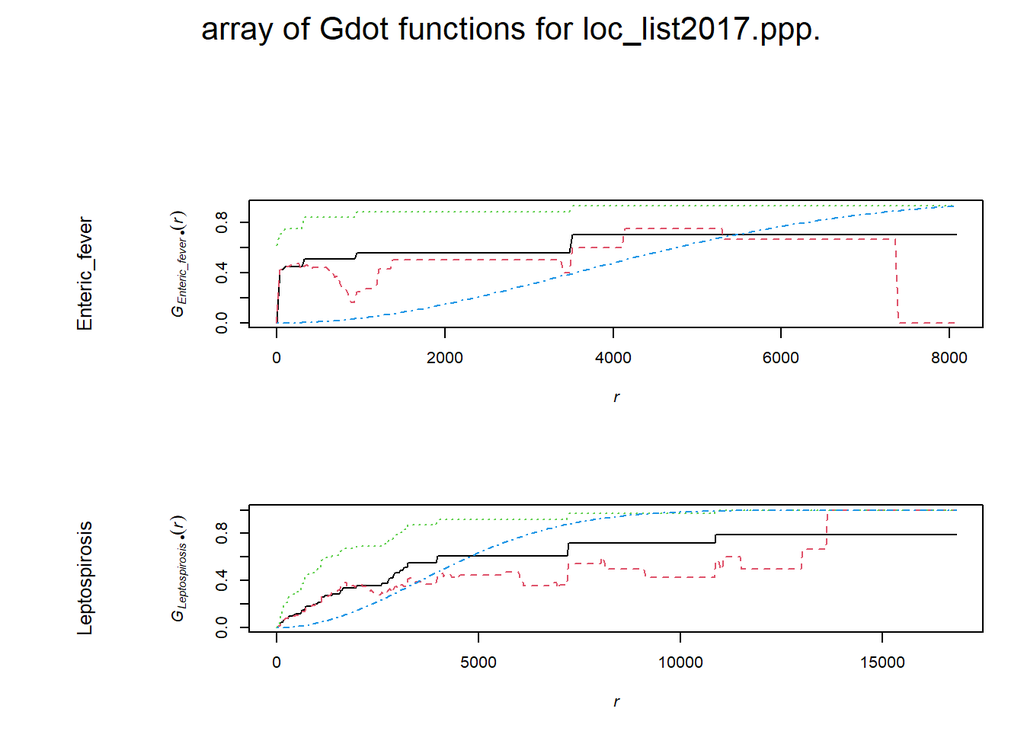

```r
plot(Gdot17)
```

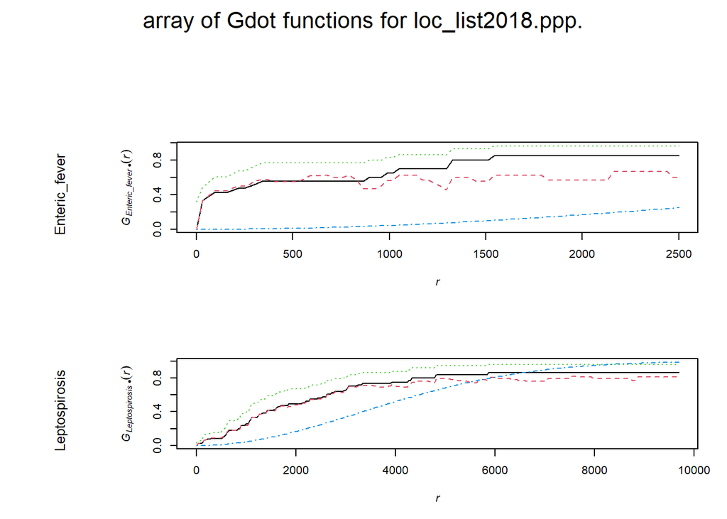

```r
plot(Gdot18)
```

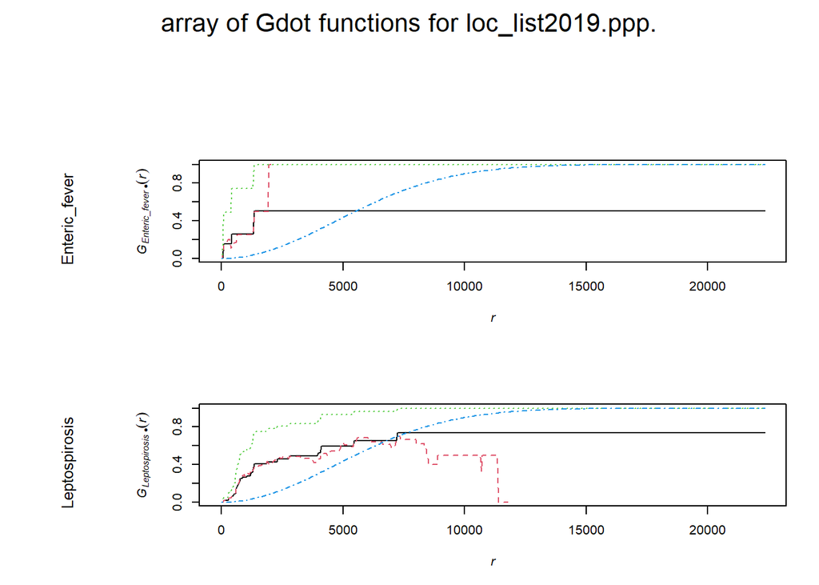

```r
plot(Gdot19)
```

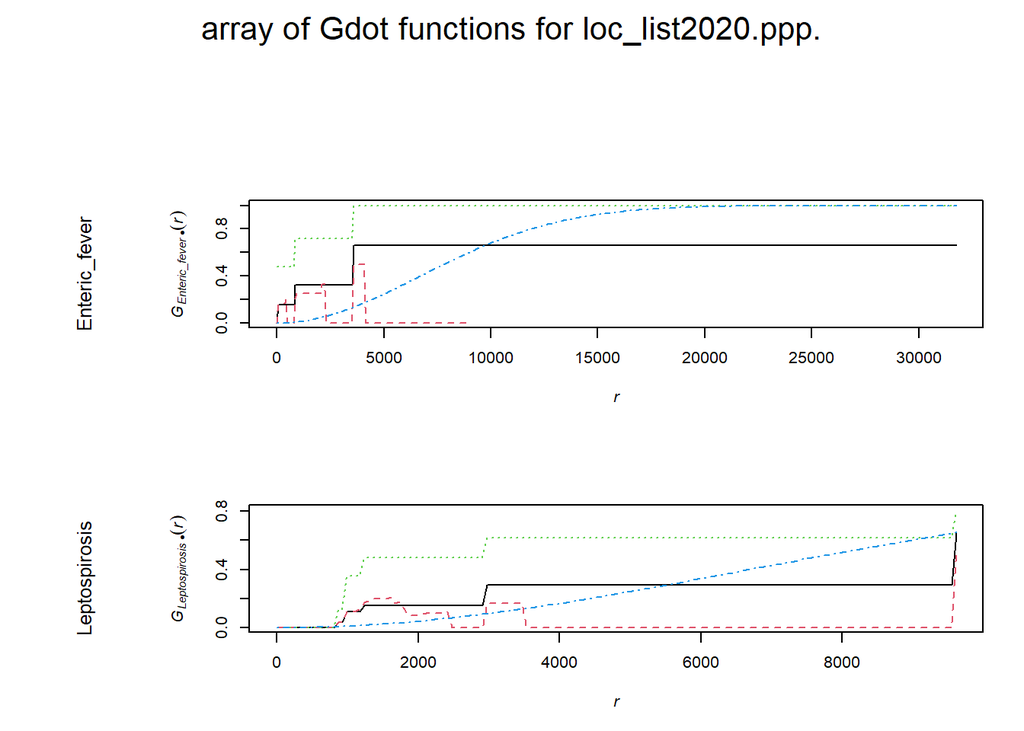

```r
plot(Gdot20)
```

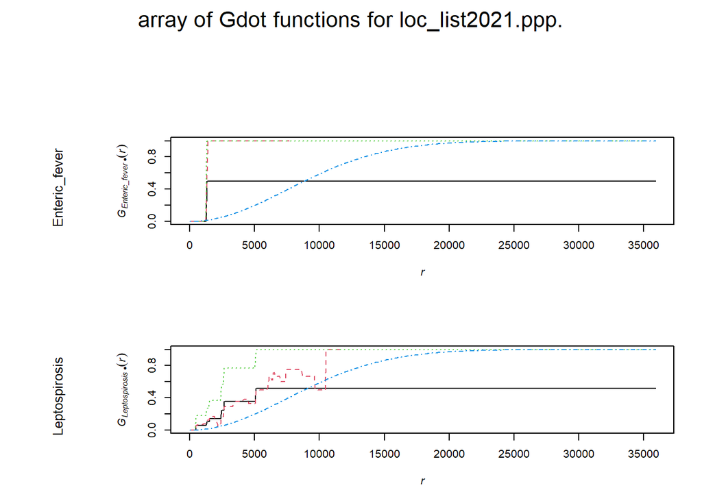

```r
plot(Gdot21)
```

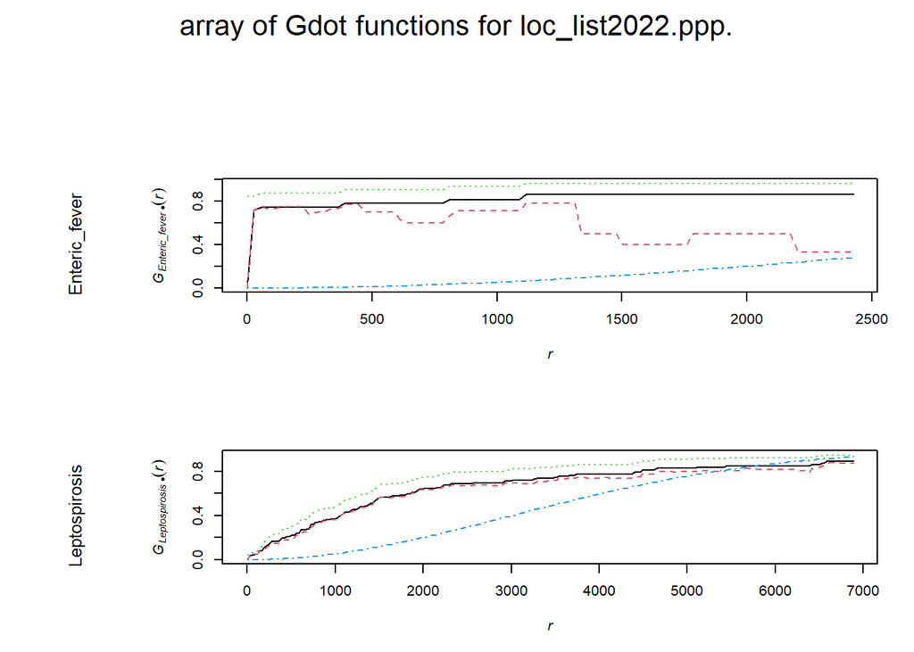

```r
plot(Gdot22)
```

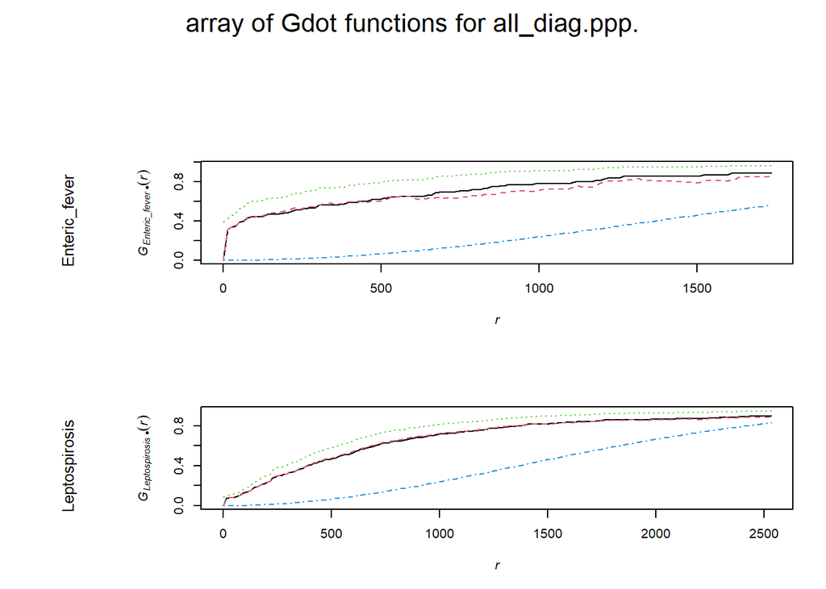

```r
plot(Gdotall)
```